# Project 2

STATS 220 Semester One 2023

(Alex) Jiacheng Wei

2023-03-27

# Introduction

### Focus

The learning preferences/habits I decided to focus on for my report was the number and types of coding languages people use relative to how long they have been coding, how they felt about some of the bigger languages, and some of the sites they may have used to assist their coding in relation to the previously state factors.

### Considered Guildline

One of the guidelines I considered was guideline 3 where I allowed

*“Which programming concepts do you understand”*

and

*“Which of the following websites do you use to assist”*

as some people may have somehow program without learning any concepts and some people may not use any website to assist with their coding such as instead using a book.

I also left out a large number of possible websites and all possible programming concepts as it would be impractical to find and list them all.

### Un-“tidy”Categorical Data

The check boxes in the google form mean my data is not tidy as people who fill out the form can give no answer, but in this scenario no answer is valid as theoretically it is possible for one to never use a coding website or understand basic concepts and still code.

### Link to the Google Form

*URL*

https://docs.google.com/forms/d/e/1FAIpQLSf7xm0AncYS8XcW8Hn485Z7ViTD_27eUWL_JCVzWHO6xsYZYw/viewform?usp=sf_link

*Shortened URL* https://forms.gle/JJgv12D5ywUgwpS9A

# Analytics

### Link to published CSV file

*URL* https://docs.google.com/spreadsheets/d/e/2PACX-1vRQzTNG-VqFIOEq2oRWq4m4K0SxDHf0MB9QJWy88WTDK4ZHQiUgZu9NXoZ_AaBCCAB7Xsrg0qd-tVAa/pub?output=csv

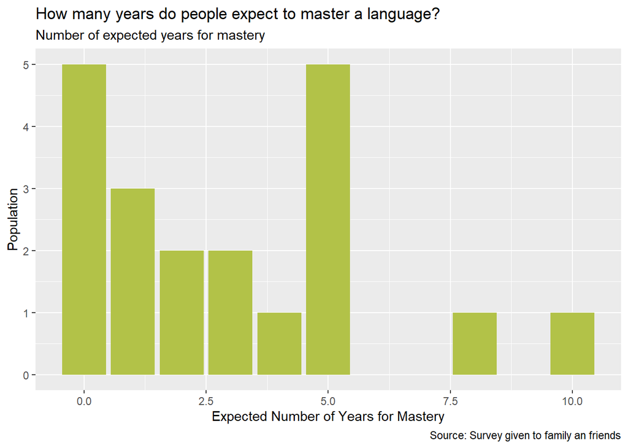

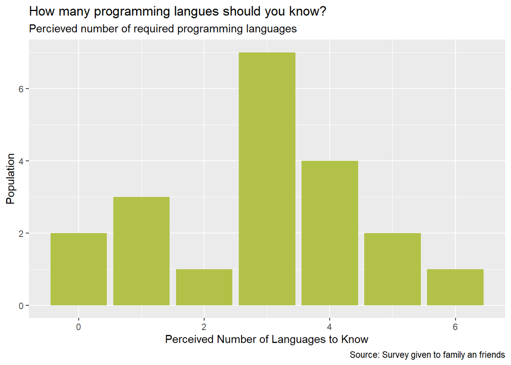

# Learning Reflection

### One important idea

One important idea I learnt from creating dynamic reporting systems is that thinking up the questions to ask is just as important and requires just as much thought as crunching the numbers do.

There are limitations to R project and other statistics based languages which we must account for, including accounting for the many different possible answers form-takers might have, and from how we word certain questions.

If form-takers misunderstand a question we have asked and anwer incorrectly, then the data will be spoilt.